# Capstone Project

#### Density Plots

```r
# Loading necessary libraries
library(tidyverse)
library(patchwork)
```

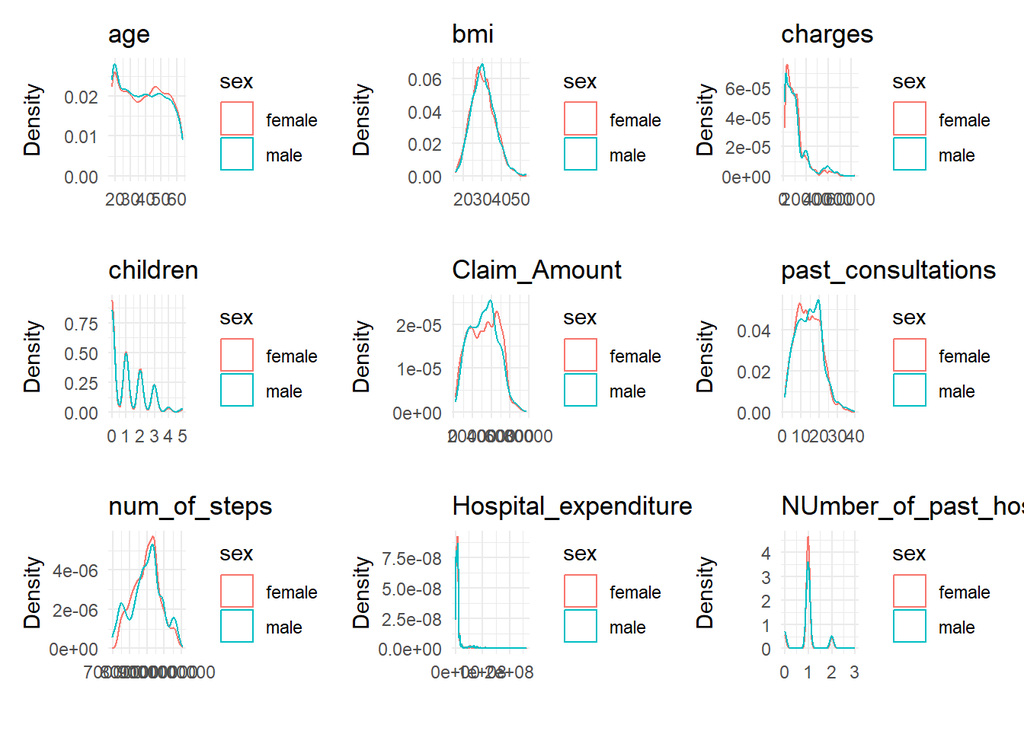

```r
# Defining the columns to plot
cols <- c("age", "bmi", "charges", "children", "Claim_Amount", "past_consultations",
          "num_of_steps", "Hospital_expenditure", "NUmber_of_past_hospitalizations")

# Creating a list to store individual plots
plot_list <- list()

# Looping through each column and create a KDE plot
for (col in cols) {
  p <- ggplot(idata2, aes_string(x = col, color = "sex")) +
    geom_density() +
    labs(x = "", y = "Density", title = col) +
    theme_minimal()
  plot_list[[length(plot_list) + 1]] <- p
}
# Combining all plots into a grid layout
combined_plot <- wrap_plots(plot_list, ncol = 3)

# Displaying the combined plot
print(combined_plot)
```

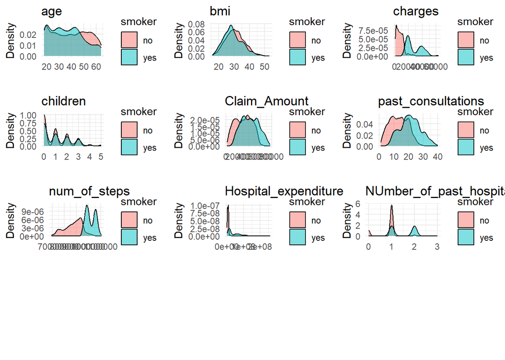

```r
# Setting up the plot canvas
plot_grid <- matrix(seq(1, 12), nrow = 4, ncol = 3, byrow = TRUE)

# Initializing an empty list to store ggplot objects
plot_list <- list()

# Creating plots for each column
for (i in seq_along(cols)) {
  # Plot KDE with ggplot2
  plot <- ggplot(idata2, aes_string(x = cols[i], fill = "smoker")) +
    geom_density(alpha = 0.5) +
    labs(title = cols[i], x = "", y = "Density") +
    theme_minimal()

  # Adding plot to list
  plot_list[[i]] <- plot
}

# Combining plots into a grid
multiplot <- cowplot::plot_grid(plotlist = plot_list, nrow = 4, ncol = 3)

# Printing the grid of plots
print(multiplot)
```

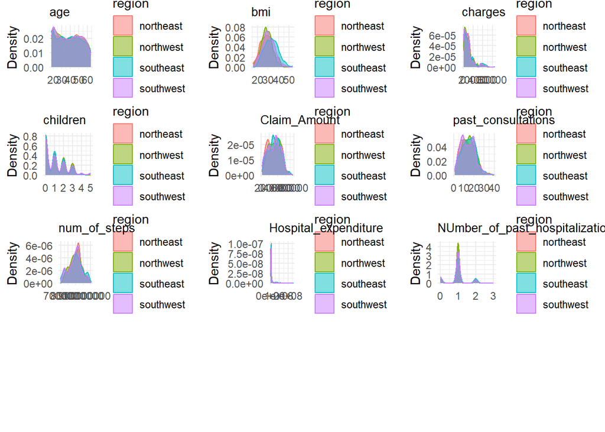

```r
# Loading required packages
library(ggplot2)
library(dplyr)
library(cowplot)
# Initializing an empty list to store ggplot objects
plot_list <- list()

# Creating plots for each column
for (col in cols) {
  # Plotting KDE with ggplot2
  p <- ggplot(idata2, aes_string(x = col, color = "region", fill = "region")) +
    geom_density(alpha = 0.5) +
    labs(title = col, x = "", y = "Density") +
    theme_minimal() +
    theme(plot.title = element_text(size = 10))

  # Adding plot to list
  plot_list[[length(plot_list) + 1]] <- p
}

# Combining plots into a grid
multiplot <- plot_grid(plotlist = plot_list, nrow = 4, ncol = 3)

# Printing the grid of plots
print(multiplot)
```

### Multivariate Analysis

#### Insurance Charges by Gender and Smoking Status

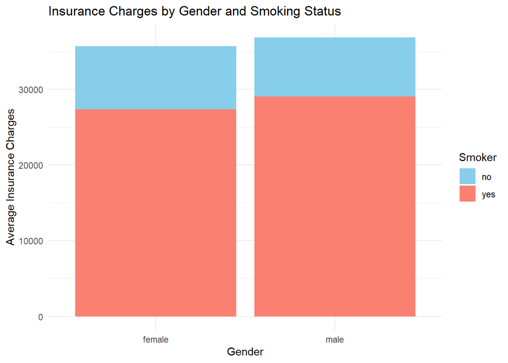

```r
# Calculating average charges by gender and smoking status
charges_by_gender_smoker <- idata2 %>%
  group_by(sex, smoker) %>%
  summarise(average_charges = mean(charges, na.rm = TRUE), .groups = 'drop')

# Creating the stacked bar plot using ggplot2
ggplot(charges_by_gender_smoker, aes(x = sex, y = average_charges, fill = smoker)) +
  geom_bar(stat = "identity") +
  labs(x = "Gender", y = "Average Insurance Charges", title = "Insurance Charges by Gender and Smoking Status") +
  scale_fill_manual(values = c("no" = "skyblue", "yes" = "salmon"), name = "Smoker") +
  theme_minimal()
```

While non-smokers of both genders benefit from lower insurance costs, a curious trend emerges for smokers. Interestingly, women who smoke appear to have lower insurance premiums compared to men who smoke. This suggests that although smoking typically increases insurance costs, there might be gender-specific factors influencing how these costs are calculated.

```r
library(dplyr)
# Loading necessary libraries
library(tidyverse)


# Converting categorical variables to factors and then to numeric codes
insurance_data6 <- insur_data5 %>%
  mutate(across(where(is.character), as.factor)) %>%
  mutate(across(where(is.factor), as.integer))

# Checking the structure of the modified dataframe
str(insurance_data6)
```

```
## 'data.frame':    9066 obs. of  12 variables:
##  $ age                            : num  45 64 19 36 19 34 47 63 19 20 ...
##  $ sex                            : int  2 2 1 2 1 2 1 1 1 1 ...
##  $ bmi                            : num  28.7 34.5 32.1 28.9 24.6 ...
##  $ children                       : num  2 0 0 3 1 0 1 0 1 0 ...
##  $ smoker                         : int  1 1 1 1 1 1 1 1 1 1 ...
##  $ Claim_Amount                   : num  32994 38448 50778 33741 12198 ...
##  $ past_consultations             : num  16 8 15 10 16 5 23 7 3 10 ...
##  $ num_of_steps                   : num  902022 956604 758688 879560 793026 ...
##  $ Hospital_expenditure           : num  8640895 11022389 1642626 1985637 10009377 ...
##  $ NUmber_of_past_hospitalizations: num  1 1 0 1 1 1 1 1 0 0 ...
##  $ region                         : int  4 4 2 1 2 3 4 2 4 3 ...
##  $ charges                        : num  8028 13823 2131 6749 2709 ...
```

```r
summary(insurance_data6)
```

```
##       age             sex             bmi           children
##  Min.   :18.00   Min.   :1.000   Min.   :15.96   Min.   :0.000
##  1st Qu.:26.00   1st Qu.:1.000   1st Qu.:25.80   1st Qu.:0.000
##  Median :38.00   Median :1.000   Median :29.80   Median :1.000
##  Mean   :38.59   Mean   :1.488   Mean   :30.05   Mean   :1.054
##  3rd Qu.:50.00   3rd Qu.:2.000   3rd Qu.:33.88   3rd Qu.:2.000
##  Max.   :64.00   Max.   :2.000   Max.   :46.53   Max.   :5.000
##      smoker       Claim_Amount   past_consultations  num_of_steps
##  Min.   :1.000   Min.   : 1920   Min.   : 1.00      Min.   : 695430
##  1st Qu.:1.000   1st Qu.:18590   1st Qu.: 9.00      1st Qu.: 831898
##  Median :1.000   Median :31301   Median :13.00      Median : 894307
##  Mean   :1.081   Mean   :30865   Mean   :13.52      Mean   : 882164
##  3rd Qu.:1.000   3rd Qu.:42750   3rd Qu.:19.00      3rd Qu.: 939250
##  Max.   :2.000   Max.   :65600   Max.   :29.00      Max.   :1030215
##  Hospital_expenditure NUmber_of_past_hospitalizations     region
##  Min.   :   29453     Min.   :0.0000                  Min.   :1.000
##  1st Qu.: 3472777     1st Qu.:1.0000                  1st Qu.:2.000
##  Median : 6361727     Median :1.0000                  Median :2.000
##  Mean   : 6493715     Mean   :0.8776                  Mean   :2.495
##  3rd Qu.: 8962515     3rd Qu.:1.0000                  3rd Qu.:3.000
##  Max.   :18205410     Max.   :2.0000                  Max.   :4.000
##     charges
##  Min.   : 1122
##  1st Qu.: 4135
##  Median : 7730
##  Mean   : 8603
##  3rd Qu.:11881
##  Max.   :26019
```

#### Correlation Matrix

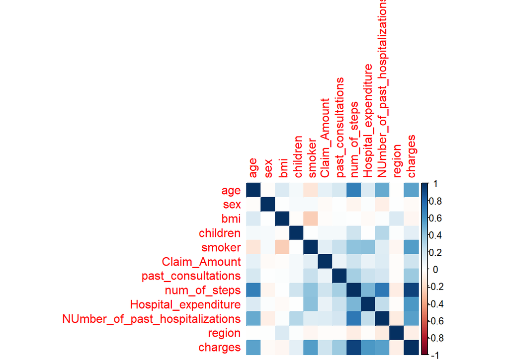

```r
# Calculating the correlation matrix, ensuring all are numeric
cor_matrix <- cor(insurance_data6, use = "pairwise.complete.obs")

# Loading library for plotting
library(corrplot)
# Plotting the correlation matrix
corrplot(cor_matrix, method = "color")
```

### Feature Selection

#### ANOVA

```r
# Performing ANOVA to select features
anova_results <- anova(lm(charges ~ ., data = insurance_data6))

print(anova_results)
```

```
## Analysis of Variance Table
##
## Response: charges
##                                   Df     Sum Sq    Mean Sq    F value    Pr(>F)
## age                                1 7.6811e+10 7.6811e+10 36508.6709 < 2.2e-16
## sex                                1 9.2306e+07 9.2306e+07    43.8737 3.702e-11
## bmi                                1 4.2513e+09 4.2513e+09  2020.6803 < 2.2e-16
## children                           1 2.4015e+09 2.4015e+09  1141.4438 < 2.2e-16
## smoker                             1 1.0478e+11 1.0478e+11 49801.3670 < 2.2e-16
## Claim_Amount                       1 1.0816e+09 1.0816e+09   514.1157 < 2.2e-16
## past_consultations                 1 3.8366e+09 3.8366e+09  1823.5787 < 2.2e-16
## num_of_steps                       1 5.2422e+10 5.2422e+10 24916.8226 < 2.2e-16
## Hospital_expenditure               1 3.1821e+09 3.1821e+09  1512.4640 < 2.2e-16
## NUmber_of_past_hospitalizations    1 3.3635e+09 3.3635e+09  1598.7211 < 2.2e-16
## region                             1 1.1055e+06 1.1055e+06     0.5255    0.4685
## Residuals                       9054 1.9049e+10 2.1039e+06
##
## age                             ***
## sex                             ***
## bmi                             ***
## children                        ***
## smoker                          ***
## Claim_Amount                    ***
## past_consultations              ***
## num_of_steps                    ***
## Hospital_expenditure            ***
## NUmber_of_past_hospitalizations ***
## region
## Residuals
## ---
## Signif. codes:  0 '***' 0.001 '**' 0.01 '*' 0.05 '.' 0.1 ' ' 1
```

```r
sum(is.na(insurance_data6))
```

```
## [1] 0
```

### Principal Component Analysis

```r
# Loading necessary libraries
library(dplyr)

# Defining the function to remove constant columns
remove_constant_columns <- function(data) {
  data_clean <- data[, sapply(data, function(col) var(col, na.rm = TRUE) > 0)]
  return(data_clean)
}



# Removing constant columns from insurance_data6
insurance_data6_clean <- remove_constant_columns(insurance_data6)

# Checking the cleaned data
summary(insurance_data6_clean)
```

```
##       age             sex             bmi           children
##  Min.   :18.00   Min.   :1.000   Min.   :15.96   Min.   :0.000
##  1st Qu.:26.00   1st Qu.:1.000   1st Qu.:25.80   1st Qu.:0.000
##  Median :38.00   Median :1.000   Median :29.80   Median :1.000
##  Mean   :38.59   Mean   :1.488   Mean   :30.05   Mean   :1.054
##  3rd Qu.:50.00   3rd Qu.:2.000   3rd Qu.:33.88   3rd Qu.:2.000
##  Max.   :64.00   Max.   :2.000   Max.   :46.53   Max.   :5.000
##      smoker       Claim_Amount   past_consultations  num_of_steps
##  Min.   :1.000   Min.   : 1920   Min.   : 1.00      Min.   : 695430
##  1st Qu.:1.000   1st Qu.:18590   1st Qu.: 9.00      1st Qu.: 831898
##  Median :1.000   Median :31301   Median :13.00      Median : 894307
##  Mean   :1.081   Mean   :30865   Mean   :13.52      Mean   : 882164
##  3rd Qu.:1.000   3rd Qu.:42750   3rd Qu.:19.00      3rd Qu.: 939250
##  Max.   :2.000   Max.   :65600   Max.   :29.00      Max.   :1030215
##  Hospital_expenditure NUmber_of_past_hospitalizations     region
##  Min.   :   29453     Min.   :0.0000                  Min.   :1.000
##  1st Qu.: 3472777     1st Qu.:1.0000                  1st Qu.:2.000
##  Median : 6361727     Median :1.0000                  Median :2.000
##  Mean   : 6493715     Mean   :0.8776                  Mean   :2.495
##  3rd Qu.: 8962515     3rd Qu.:1.0000                  3rd Qu.:3.000
##  Max.   :18205410     Max.   :2.0000                  Max.   :4.000
##     charges
##  Min.   : 1122
##  1st Qu.: 4135
##  Median : 7730
##  Mean   : 8603
##  3rd Qu.:11881
##  Max.   :26019
```

```r
# Performing PCA on the cleaned data
pca_result <- prcomp(insurance_data6_clean, scale. = TRUE, center = TRUE)

# Summarizing the PCA results
summary(pca_result)
```

```
## Importance of components:
##                          PC1    PC2     PC3     PC4     PC5     PC6     PC7
## Standard deviation     1.913 1.2365 1.06587 1.01769 0.99296 0.96650 0.91240
## Proportion of Variance 0.305 0.1274 0.09467 0.08631 0.08216 0.07784 0.06937
## Cumulative Proportion  0.305 0.4324 0.52707 0.61337 0.69554 0.77338 0.84275
##                            PC8     PC9    PC10    PC11    PC12
## Standard deviation     0.87357 0.73332 0.63903 0.38507 0.17159
## Proportion of Variance 0.06359 0.04481 0.03403 0.01236 0.00245
## Cumulative Proportion  0.90635 0.95116 0.98519 0.99755 1.00000
```

#### Scree Plot

```r
# Visualizing the variance explained by the principal components
library(factoextra)
```

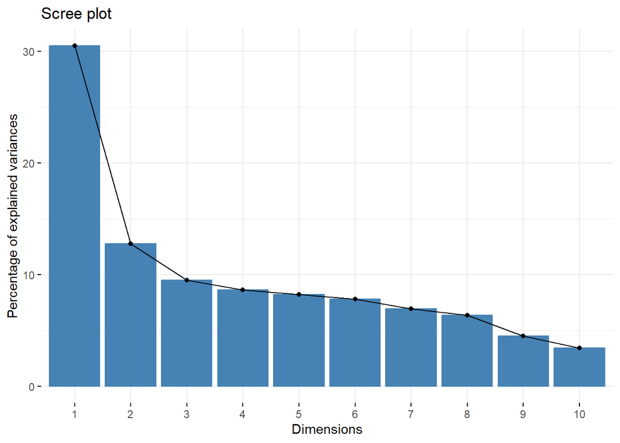

```r
fviz_eig(pca_result)
```

#### PCA Biplot

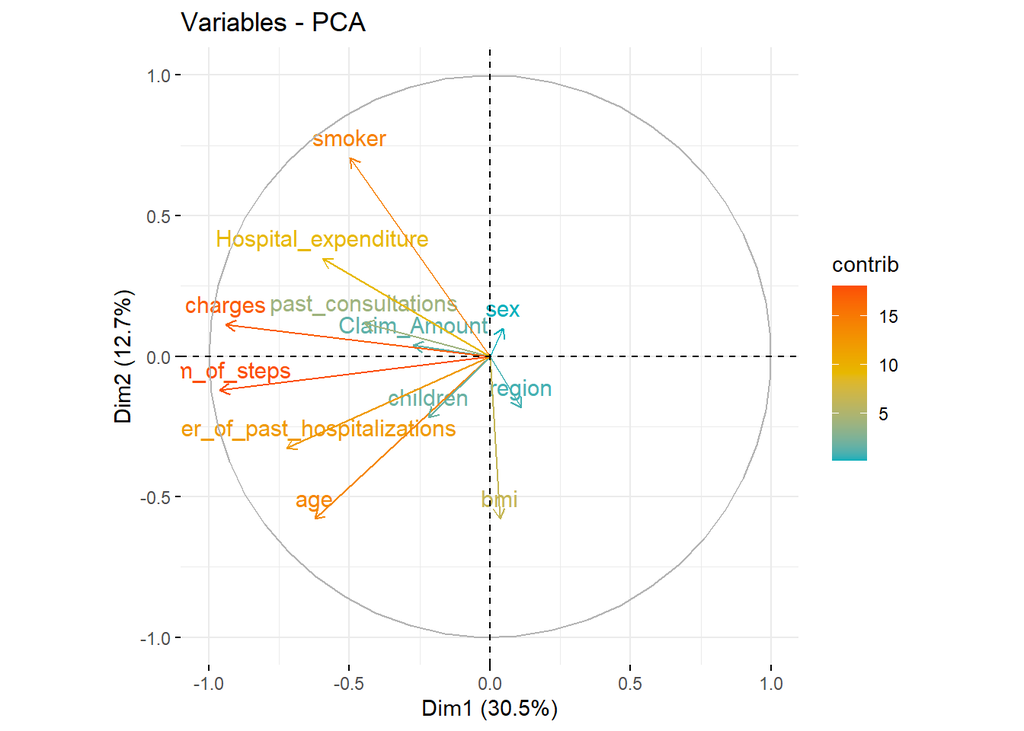

```r
#Visualizing PCA biplot
fviz_pca_var(pca_result, col.var = "contrib",
             gradient.cols = c("#00AFBB", "#E7B800", "#FC4E07")
             )
```

From PCA Biplot, the selected features are past_consultations, Hospital_expenditure, smoker, age, num_of_steps. These are selected from the assumption that features are perpendicular to target variable- charges are avoided and features with strong correlation towards or opposite to target variable are generally selected.

#### Selecting the Features

```r
# List of selected feature names based on PCA biplot correlation with the class
selected_features <- c("charges", "past_consultations", "Hospital_expenditure", "smoker", "age", "num_of_steps")


# Creating a new dataset with only the selected features
selected_data <- insurance_data6[, selected_features]

# Checking the structure of the new dataset to confirm the features are correctly selected
str(selected_data)
```

```
## 'data.frame':    9066 obs. of  6 variables:
##  $ charges             : num  8028 13823 2131 6749 2709 ...
##  $ past_consultations  : num  16 8 15 10 16 5 23 7 3 10 ...
##  $ Hospital_expenditure: num  8640895 11022389 1642626 1985637 10009377 ...
##  $ smoker              : int  1 1 1 1 1 1 1 1 1 1 ...
##  $ age                 : num  45 64 19 36 19 34 47 63 19 20 ...
##  $ num_of_steps        : num  902022 956604 758688 879560 793026 ...
```

#### PCA Biplot after selecting Features

```r
# Loading necessary libraries
library(dplyr)
library(factoextra)

# Defining the function to remove constant columns
remove_constant_columns <- function(data) {
  data_clean <- data[, sapply(data, function(col) var(col, na.rm = TRUE) > 0)]
  return(data_clean)
}


# Removing constant columns from selected_data
selected_data_clean <- remove_constant_columns(selected_data)

# Checking the cleaned data
summary(selected_data_clean)
```

```
##     charges      past_consultations Hospital_expenditure     smoker
##  Min.   : 1122   Min.   : 1.00      Min.   :   29453     Min.   :1.000
##  1st Qu.: 4135   1st Qu.: 9.00      1st Qu.: 3472777     1st Qu.:1.000
##  Median : 7730   Median :13.00      Median : 6361727     Median :1.000
##  Mean   : 8603   Mean   :13.52      Mean   : 6493715     Mean   :1.081
##  3rd Qu.:11881   3rd Qu.:19.00      3rd Qu.: 8962515     3rd Qu.:1.000
##  Max.   :26019   Max.   :29.00      Max.   :18205410     Max.   :2.000
##       age         num_of_steps
##  Min.   :18.00   Min.   : 695430
##  1st Qu.:26.00   1st Qu.: 831898
##  Median :38.00   Median : 894307
##  Mean   :38.59   Mean   : 882164
##  3rd Qu.:50.00   3rd Qu.: 939250
##  Max.   :64.00   Max.   :1030215
```

```r
# Performing PCA on the cleaned data
pca_result1 <- prcomp(selected_data_clean, scale. = TRUE, center = TRUE)

# Summarizing the PCA results
summary(pca_result1)
```

```
## Importance of components:
##                           PC1    PC2    PC3     PC4     PC5     PC6
## Standard deviation     1.7716 1.1148 0.9101 0.75804 0.41108 0.21573
## Proportion of Variance 0.5231 0.2071 0.1381 0.09577 0.02816 0.00776
## Cumulative Proportion  0.5231 0.7303 0.8683 0.96408 0.99224 1.00000
```

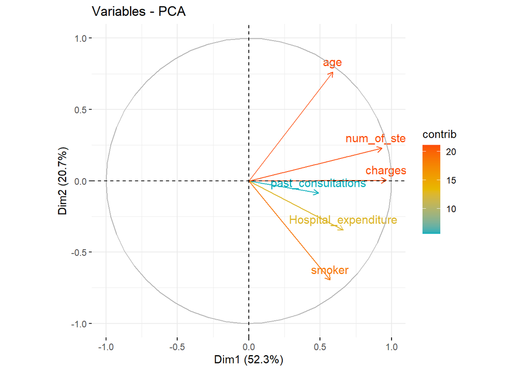

```r
# Visualizing PCA variable contributions
fviz_pca_var(pca_result1, col.var = "contrib",
             gradient.cols = c("#00AFBB", "#E7B800", "#FC4E07"))
```

#### Pair Metrics

```r
library(GGally)
```

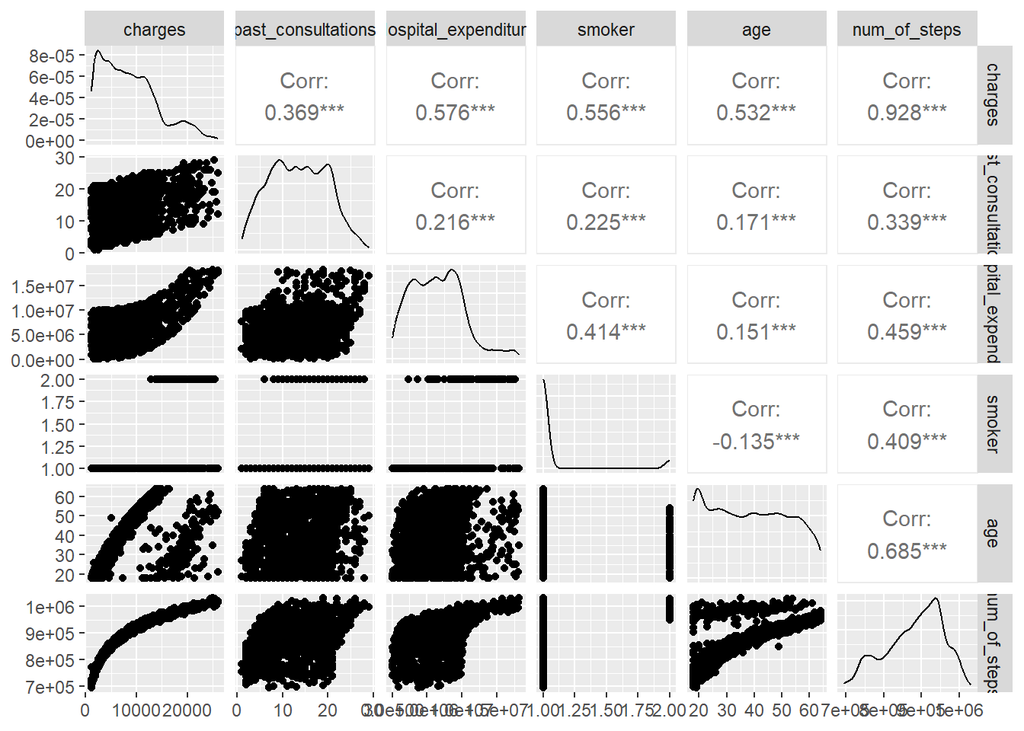

```r
ggpairs(selected_data)
```

#### Normalizing the data

```r
# Standardizing the data
norm_data <- scale(selected_data[, -which(names(selected_data) == "charges")])


norm_data <- as.data.frame(norm_data)  # Convert to data frame
norm_data$charges <- selected_data$charges

head(norm_data)
```

```
##   past_consultations Hospital_expenditure     smoker        age num_of_steps
## 1          0.3987813            0.5748157 -0.2974496  0.4617174   0.26955993
## 2         -0.8861629            1.2123592 -0.2974496  1.8300447   1.01047485
## 3          0.2381632           -1.2986722 -0.2974496 -1.4107307  -1.67610531
## 4         -0.5649268           -1.2068454 -0.2974496 -0.1864377  -0.03534702
## 5          0.3987813            0.9411684 -0.2974496 -1.4107307  -1.20998944
## 6         -1.3680169            0.6915150 -0.2974496 -0.3304722  -0.68168948
##     charges
## 1  8027.968
## 2 13822.803
## 3  2130.676
## 4  6748.591
## 5  2709.244
## 6  3935.180
```

### Model Building

#### Data Splitting

```r
library(caret)
# Spliting data into training and testing sets
set.seed(123)  # For reproducibility
trainIndex <- createDataPartition(norm_data$charges, p = .8,
                                  list = FALSE,
                                  times = 1)
insurance_train <- norm_data[trainIndex, ]
insurance_test  <- norm_data[-trainIndex, ]
```

```r
summary(insurance_train)
```

```
##  past_consultations   Hospital_expenditure     smoker
##  Min.   :-2.0104890   Min.   :-1.730530    Min.   :-0.297450
##  1st Qu.:-0.8861629   1st Qu.:-0.813126    1st Qu.:-0.297450
##  Median :-0.0830728   Median :-0.035334    Median :-0.297450
##  Mean   :-0.0008045   Mean   :-0.001026    Mean   : 0.004651
##  3rd Qu.: 0.8806353   3rd Qu.: 0.660843    3rd Qu.:-0.297450
##  Max.   : 2.4868155   Max.   : 3.135307    Max.   : 3.361543
##       age            num_of_steps          charges
##  Min.   :-1.48275   Min.   :-2.534791   Min.   : 1122
##  1st Qu.:-0.90661   1st Qu.:-0.681242   1st Qu.: 4136
##  Median :-0.04240   Median : 0.164834   Median : 7730
##  Mean   : 0.00181   Mean   : 0.001092   Mean   : 8605
##  3rd Qu.: 0.82180   3rd Qu.: 0.776168   3rd Qu.:11881
##  Max.   : 1.83004   Max.   : 2.009696   Max.   :26019
```

#### 1. Linear Regression Model

```r
# Linear Regression Model
lm_model <- train(charges ~ ., data = insurance_train, method = "lm")
summary(lm_model)
```

```
##
## Call:
## lm(formula = .outcome ~ ., data = dat)
##
## Residuals:
##     Min      1Q  Median      3Q     Max
## -4191.9 -1154.2  -187.1   853.6  7979.0
##
## Coefficients:
##                      Estimate Std. Error t value Pr(>|t|)
## (Intercept)           8597.37      18.94 453.823  < 2e-16 ***
## past_consultations     194.07      20.22   9.599  < 2e-16 ***
## Hospital_expenditure   751.55      22.39  33.566  < 2e-16 ***
## smoker                 870.02      26.94  32.292  < 2e-16 ***
## age                   -114.32      33.83  -3.379 0.000731 ***
## num_of_steps          4376.55      38.59 113.409  < 2e-16 ***
## ---
## Signif. codes:  0 '***' 0.001 '**' 0.01 '*' 0.05 '.' 0.1 ' ' 1
##
## Residual standard error: 1614 on 7249 degrees of freedom
## Multiple R-squared:  0.9133, Adjusted R-squared:  0.9132
## F-statistic: 1.527e+04 on 5 and 7249 DF,  p-value: < 2.2e-16
```

```r
# Model prediction and evaluation
lm_predictions <- predict(lm_model, newdata = insurance_test)
lm_rmse <- RMSE(lm_predictions, insurance_test$charges)
print(paste("Linear Model RMSE:", lm_rmse))
```

```
## [1] "Linear Model RMSE: 1567.39979522638"
```

This linear regression model effectively predicts the outcome variable (R-squared: 0.9132) with all independent variables (past consultations, hospital expenditure, smoker status, age, and steps) having a significant impact (p-value < 0.05). While the intercept represents the outcome when all other factors are zero, the coefficients indicate the direction and strength of each variable’s influence, with age showing a negative effect. The RMSE of 1567.40 suggests an average difference between predicted and actual outcomes.

#### Addressing Model Assumptions - Linear Regression

- Residuals vs Fitted: This plot checks the linearity assumption.
- Normal Q-Q: This plot checks the normality of residuals.
- Scale-Location (or Spread-Location): This plot checks the homoscedasticity assumption.
- Residuals vs Leverage: This plot identifies influential observations.

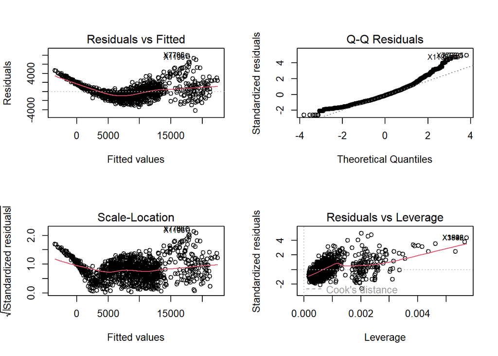

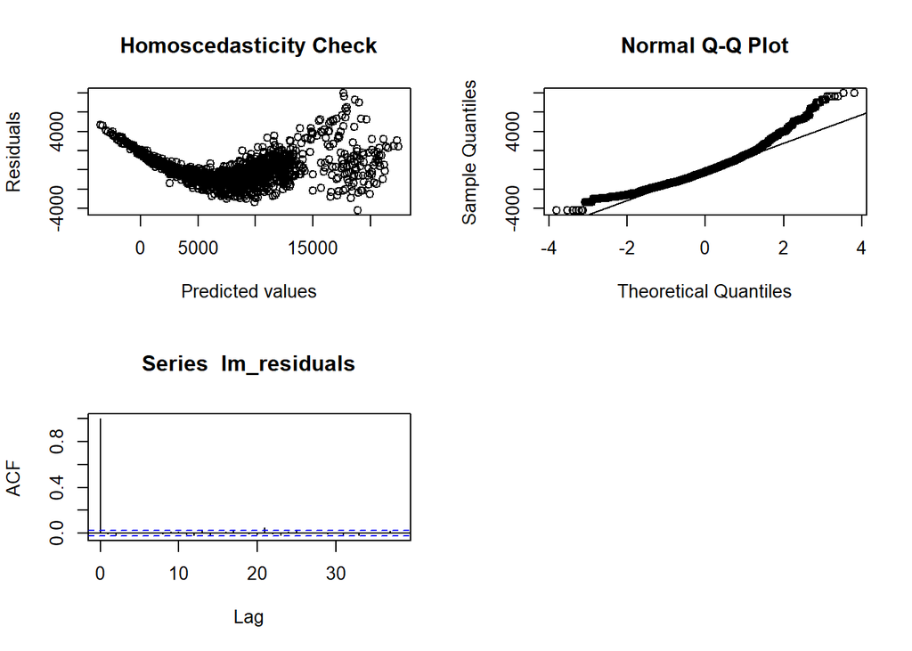

```r
# Addressing Model Assumptions for Linear Regression

# Checking lengths of predicted values and residuals
lm_predictions <- predict(lm_model$finalModel)
lm_residuals <- residuals(lm_model$finalModel)

# Ensuring the lengths are the same
if(length(lm_predictions) == length(lm_residuals)) {
  # Residual plots
  par(mfrow = c(2, 2))
  plot(lm_model$finalModel)

  # Checking for homoscedasticity
  plot(lm_predictions, lm_residuals, main = "Homoscedasticity Check", xlab = "Predicted values", ylab = "Residuals")

  # Checking for normality of residuals
  qqnorm(lm_residuals)
  qqline(lm_residuals)

  # Independence of residuals
  acf(lm_residuals)
} else {
  stop("Lengths of predicted values and residuals do not match.")
}
```

1. Residuals vs Fitted

Ideally, the residuals should be randomly scattered around the horizontal line (residuals = 0) with no clear pattern. In the plot, the residuals display a curved pattern, which suggests that the linearity assumption may be violated. This indicates that the relationship between the predictors and the response variable may not be purely linear.

2. Normal Q-Q

Ideally, the residuals should fall along the 45-degree reference line. In the plot, most residuals fall along the line, but there are deviations at the tails (particularly at the upper end), indicating some departure from normality. This suggests that the residuals may not be perfectly normally distributed, but moderate deviations are usually acceptable.

3. Scale-Location (or Spread-Location)

In the plot, the spread of the standardized residuals increases with the fitted values, suggesting heteroscedasticity (non-constant variance). This means that the variance of the residuals increases as the fitted values increase, which violates the homoscedasticity assumption.

4. Residuals vs Leverage

Points that are far from others horizontally (high leverage) and have large residuals vertically (outliers) can be influential. In the plot, a few points are highlighted (e.g., point labeled X38880) with high leverage or high Cook’s distance, indicating they are potentially influential. Such points can have a significant impact on the regression model and should be investigated further.

Homoscedasticity

In this plot, it appears there is a slight trend upwards as the predicted values increase. This suggests that the variance of the residuals might be increasing with increasing predicted values, violating the assumption of homoscedasticity.

Normality of residuals

If the residuals are normally distributed, the points should fall approximately along a straight diagonal line. In this plot, the points deviate from the straight line, particularly for the tails of the distribution. This suggests that the residuals may not be normally distributed.

### 2. Decision Tree Model

```r
# Loading necessary package
library(rpart)

# Decision Tree model
tree_model <- rpart(charges ~ ., data = insurance_train)

# Summary of the Decision Tree model
summary(tree_model)
```

```
## Call:
## rpart(formula = charges ~ ., data = insurance_train)
##   n= 7255
##
##           CP nsplit  rel error     xerror        xstd
## 1 0.66600622      0 1.00000000 1.00019421 0.016603603
## 2 0.15723563      1 0.33399378 0.33577196 0.005970079
## 3 0.09267839      2 0.17675815 0.17319715 0.002293408
## 4 0.01563575      3 0.08407976 0.08532524 0.001546314
## 5 0.01540218      4 0.06844401 0.07092629 0.001473070
## 6 0.01087680      5 0.05304182 0.05919804 0.001341385
## 7 0.01000000      6 0.04216502 0.04552195 0.000941466
##
## Variable importance
##         num_of_steps                  age Hospital_expenditure
##                   44                   25                   14
##               smoker   past_consultations
##                   10                    7
##
## Node number 1: 7255 observations,    complexity param=0.6660062
##   mean=8605.064, MSE=2.999775e+07
##   left son=2 (4419 obs) right son=3 (2836 obs)
##   Primary splits:
##       num_of_steps         < 0.446902     to the left,  improve=0.6660062, (0 missing)
##       Hospital_expenditure < 1.140119     to the left,  improve=0.3643844, (0 missing)
##       smoker               < 1.532047     to the left,  improve=0.3122279, (0 missing)
##       age                  < -0.006394647 to the left,  improve=0.2150786, (0 missing)
##       past_consultations   < 1.28218      to the left,  improve=0.1310987, (0 missing)
##   Surrogate splits:
##       age                  < 0.7137777    to the left,  agree=0.826, adj=0.555, (0 split)
##       Hospital_expenditure < 0.9660037    to the left,  agree=0.735, adj=0.321, (0 split)
##       smoker               < 1.532047     to the left,  agree=0.692, adj=0.211, (0 split)
##       past_consultations   < 1.28218      to the left,  agree=0.679, adj=0.179, (0 split)
##
## Node number 2: 4419 observations,    complexity param=0.09267839
##   mean=5024.309, MSE=6240164
##   left son=4 (2617 obs) right son=5 (1802 obs)
##   Primary splits:
##       num_of_steps         < -0.259378    to the left,  improve=0.73144990, (0 missing)
##       age                  < -0.438498    to the left,  improve=0.69554430, (0 missing)
```

[output cut: 69 more lines]

```
##
## Node number 9: 1211 observations
##   mean=4480.171, MSE=480010.4
##
## Node number 12: 1076 observations
##   mean=10782.64, MSE=1196695
##
## Node number 13: 952 observations
##   mean=13358.75, MSE=1661721
##
## Node number 14: 427 observations
##   mean=18070.91, MSE=2444431
##
## Node number 15: 381 observations
##   mean=21499.71, MSE=3308855
```

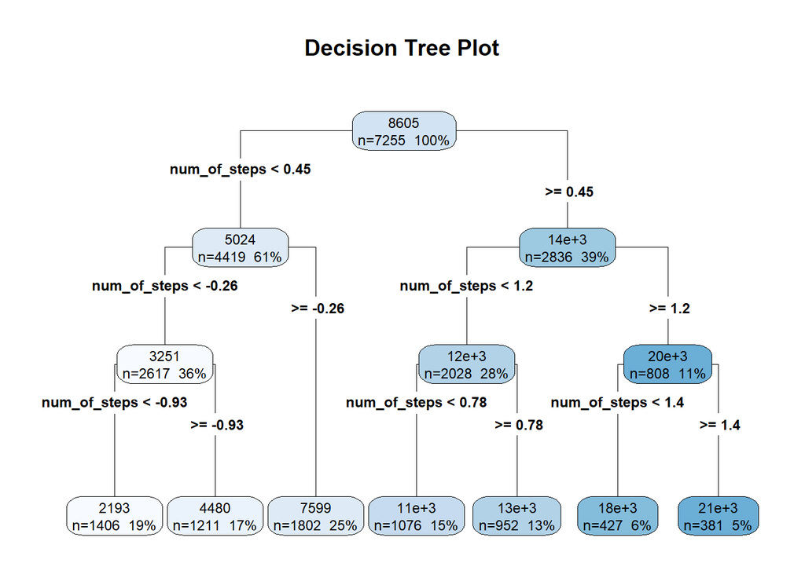

```r
# Loading the necessary library
library(rpart.plot)
# Plotting the regression tree
rpart.plot(tree_model, main="Decision Tree Plot", type=4, extra=101)  # Adjust the type and extra for regression tree
```

#### Addressing Model Assumptions- Decision Tree

```r
library(rpart)
library(rpart.plot)
library(caret)
```

```r
# Predicting on the training data
train_predictions <- predict(tree_model, newdata = insurance_train)

# Predicting on the test data
test_predictions <- predict(tree_model, newdata = insurance_test)

# Evaluating model performance
train_mse <- mean((insurance_train$charges - train_predictions)^2)
train_rmse <- sqrt(train_mse)
train_r2 <- R2(train_predictions, insurance_train$charges)

test_mse <- mean((insurance_test$charges - test_predictions)^2)
test_rmse <- sqrt(test_mse)
test_r2 <- R2(test_predictions, insurance_test$charges)

cat("Training RMSE:", train_rmse, "\n")
```

```
## Training RMSE: 1124.658
```

```r
cat("Training R-squared:", train_r2, "\n")
```

```
## Training R-squared: 0.957835
```

```r
cat("Test RMSE:", test_rmse, "\n")
```

```
## Test RMSE: 1162.545
```

```r
cat("Test R-squared:", test_r2, "\n")
```

```
## Test R-squared: 0.954468
```

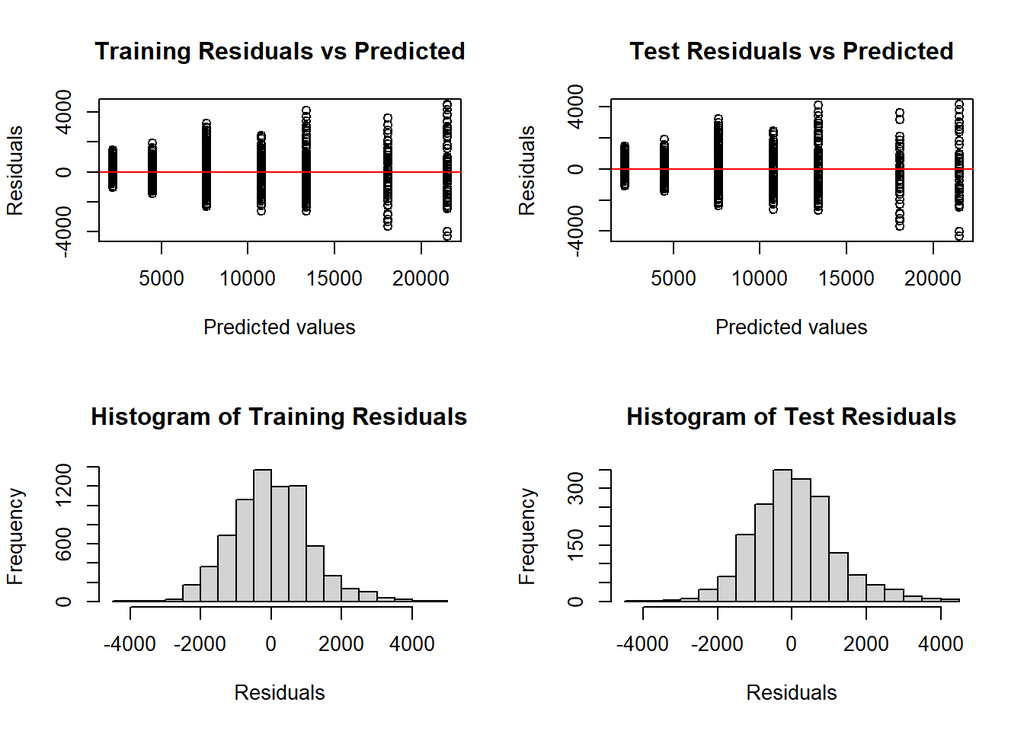

```r
# Plotting residuals
train_residuals <- insurance_train$charges - train_predictions
test_residuals <- insurance_test$charges - test_predictions

# Plotting training residuals
par(mfrow = c(2, 2))
plot(train_predictions, train_residuals, main = "Training Residuals vs Predicted",
     xlab = "Predicted values", ylab = "Residuals")
abline(h = 0, col = "red")

# Plotting test residuals
plot(test_predictions, test_residuals, main = "Test Residuals vs Predicted",
     xlab = "Predicted values", ylab = "Residuals")
abline(h = 0, col = "red")

# Histogram of residuals
hist(train_residuals, main = "Histogram of Training Residuals",
     xlab = "Residuals", breaks = 30)

hist(test_residuals, main = "Histogram of Test Residuals",
     xlab = "Residuals", breaks = 30)
```

Training Residuals vs. Predicted and Test Residuals vs. Predicted: These are scatter plots of the predicted values versus the residuals for the training and test data, respectively. Again, theoretically, if things were ideal—residuals must be randomly scattered around zero with no visible pattern. In other words, this would then confirm that the model’s predictions are unbiased across the range of predicted values.

Histogram of training residuals and histogram of test residuals: These graphs estimate the density of the residuals for the training set and the test data set. The ideal shape of the histograms should be at least somewhat symmetric, or even near bell-shaped, in order to suggest that the residuals are at least approximately normally distributed. This would be assumed under linear regression, but it is not the case under decision trees per se. However, this has implications for model interpretability and estimation of confidence intervals.

### Cross Validation

```r
library(caret)
library(rpart)
```

```r
# Defining cross-validation method
train_control <- trainControl(method = "cv", number = 10)  # 10-fold cross-validation
```

#### Cross Validation - Linear Regression

```r
# Linear Regression Model with cross-validation
lm_model_cv <- train(charges ~ ., data = insurance_train, method = "lm", trControl = train_control)

# Summary of the Linear Regression model
print(lm_model_cv)
```

```
## Linear Regression
##
## 7255 samples
##    5 predictor
##
## No pre-processing
## Resampling: Cross-Validated (10 fold)
## Summary of sample sizes: 6528, 6531, 6530, 6528, 6530, 6529, ...
## Resampling results:
##
##   RMSE      Rsquared   MAE
##   1613.807  0.9132521  1243.484
##
## Tuning parameter 'intercept' was held constant at a value of TRUE
```

```r
# Predicting on the test data
lm_predictions <- predict(lm_model_cv, newdata = insurance_test)

# Evaluating model performance
lm_rmse <- RMSE(lm_predictions, insurance_test$charges)
lm_r2 <- R2(lm_predictions, insurance_test$charges)

cat("Linear Regression Model RMSE:", lm_rmse, "\n")
```

```
## Linear Regression Model RMSE: 1567.4
```

```r
cat("Linear Regression Model R-squared:", lm_r2, "\n")
```

```
## Linear Regression Model R-squared: 0.9172124
```

#### Cross Validation - Decision tree

```r
# Decision Tree model for predicting charges with cross-validation
tree_model_cv <- train(charges ~ ., data = insurance_train, method = "rpart", trControl = train_control)
# Summary of the Decision Tree model
print(tree_model_cv)
```

```
## CART
##
## 7255 samples
##    5 predictor
##
## No pre-processing
## Resampling: Cross-Validated (10 fold)
## Summary of sample sizes: 6530, 6529, 6531, 6529, 6529, 6531, ...
## Resampling results across tuning parameters:
##
##   cp          RMSE      Rsquared   MAE
##   0.09267839  2136.292  0.8449059  1771.933
##   0.15723563  2555.743  0.7767836  2116.268
##   0.66600622  4114.222  0.6588826  3345.537
##
## RMSE was used to select the optimal model using the smallest value.
## The final value used for the model was cp = 0.09267839.
```

```r
# Predicting on the test data
tree_predictions <- predict(tree_model_cv, newdata = insurance_test)

# Evaluating model performance
tree_rmse <- RMSE(tree_predictions, insurance_test$charges)
tree_r2 <- R2(tree_predictions, insurance_test$charges)

cat("Decision Tree Model RMSE:", tree_rmse, "\n")
```

```
## Decision Tree Model RMSE: 2362.393
```

```r
cat("Decision Tree Model R-squared:", tree_r2, "\n")
```

```
## Decision Tree Model R-squared: 0.8115849
```